# Walkthroughs and Exercises for Deep Learning for Business Made Simple

# Module 4: Interpreting and Communicating Deep Learning Results

A model is only as valuable as the trust and clarity you can put around it. We evaluate the **cancellation model** from Module 1 the way a business actually should.

> **Heads up:** this module reuses the trained `model` and the `X_val` / `y_val` split from Module 1, so run those cells first (in the same session) before this one.

## Walkthrough 4.1: Confusion Matrix and Business Metrics

```
%%{init: {'theme': 'base', 'themeVariables': {'fontSize': '15px'}}}%%
flowchart LR
  A[/"Actually<br/>CANCELED"/]:::anchor --> TP["Caught it<br/>(correct)"]:::good
  A --> FN["MISSED it<br/>unsold room (costly)"]:::bad
  K[/"Actually<br/>KEPT"/]:::anchor --> TN["Correct keep"]:::good
  K --> FP["False alarm<br/>(hassled a guest)"]:::warn
  classDef anchor fill:#eceff1,stroke:#546e7a,color:#1a1a1a
  classDef good fill:#d8f5d8,stroke:#2e7d32,color:#1a1a1a
  classDef bad fill:#fde0e0,stroke:#c62828,stroke-width:2px,color:#1a1a1a
  classDef warn fill:#ffe8cc,stroke:#e8730c,color:#1a1a1a
```

The confusion matrix in business terms. The missed cancellation is the costly box.

```
Majority-class baseline (always 'not canceled'): 63.0% accuracy
```

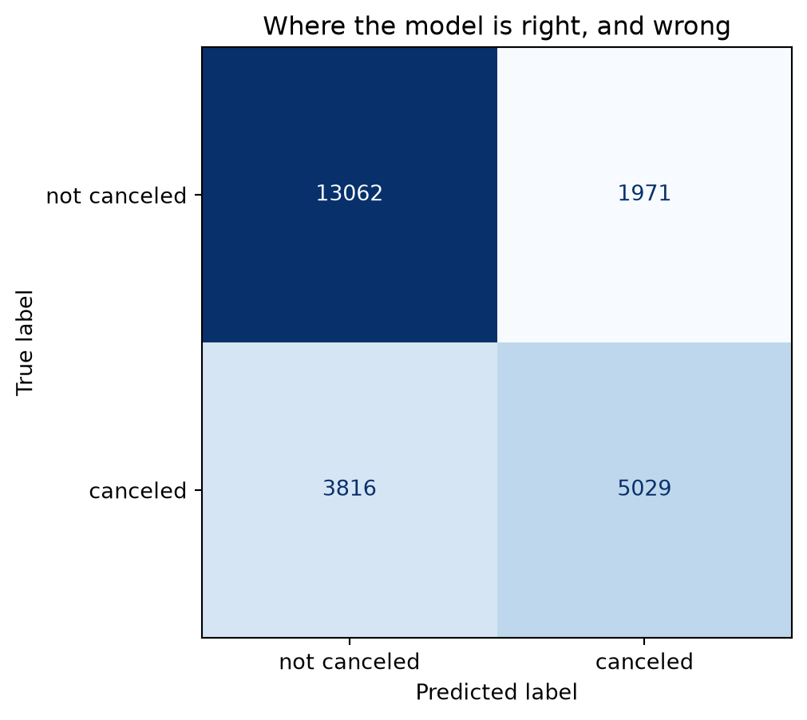

```
Precision: 0.718 | Recall: 0.569 | F1: 0.635
```

```python
from sklearn.metrics import (confusion_matrix,
                             ConfusionMatrixDisplay,
                             precision_score, recall_score,
                             f1_score)

probs = model.predict(X_val, verbose=0).ravel()
preds = (probs > 0.5).astype(int)

# The bar to beat: always guessing the majority class ("not
# canceled")
baseline = 1 - y_val.mean()
print(f"Majority-class baseline (always 'not canceled'): {baseline:.1%} accuracy")

cm = confusion_matrix(y_val, preds)
ConfusionMatrixDisplay(cm, display_labels=["not canceled", "canceled"]).plot(
    cmap="Blues", colorbar=False)
plt.title("Where the model is right, and wrong")
plt.show()

print("Precision:", round(precision_score(y_val, preds), 3),
      "| Recall:", round(recall_score(y_val, preds), 3),
      "| F1:", round(f1_score(y_val, preds), 3));
```

> **Common Pitfall:** Accuracy alone hides the costly errors. Read the confusion matrix by **business cost**: a missed cancellation (false negative) is a room you didn’t resell; a false alarm (false positive) might mean wrongly hassling a guest.

## Exercise 4.1: Tune the Threshold to the Business Trade-off

The model outputs a *probability*. **You** decide where to draw the line, and that choice is a business decision, not a default of 0.5.

```
%%{init: {'theme': 'base', 'themeVariables': {'fontSize': '16px'}}}%%
flowchart TD
  T{"Decision threshold<br/>YOU set it, not 0.5"}:::decision -->|move lower| MORE["Catch more cancels<br/>more recall, less precision"]:::accent
  T -->|move higher| FEWER["Fewer false alarms<br/>more precision, less recall"]:::proc
  MORE --> COST["Set by cost:<br/>a miss costs about<br/>4x a false alarm"]:::bad
  FEWER --> COST
  classDef decision fill:#fff3cd,stroke:#d39e00,color:#1a1a1a
  classDef accent fill:#ede0ff,stroke:#6a1b9a,color:#1a1a1a
  classDef proc fill:#dbe9ff,stroke:#1a73e8,color:#1a1a1a
  classDef bad fill:#fde0e0,stroke:#c62828,color:#1a1a1a
```

The decision threshold is a business dial: trade recall against precision by cost.

```python
print(f"{'threshold':>10} {'precision':>10} {'recall':>8}")
for thr in [0.3, 0.4, 0.5, 0.6, 0.7]:
    p = (probs > thr).astype(int)
    print(f"{thr:>10} {precision_score(y_val, p):>10.3f} {recall_score(y_val, p):>8.3f}")
```

```
 threshold  precision   recall
       0.3      0.595    0.748
       0.4      0.666    0.651
       0.5      0.718    0.569
       0.6      0.775    0.448
       0.7      0.865    0.322
```

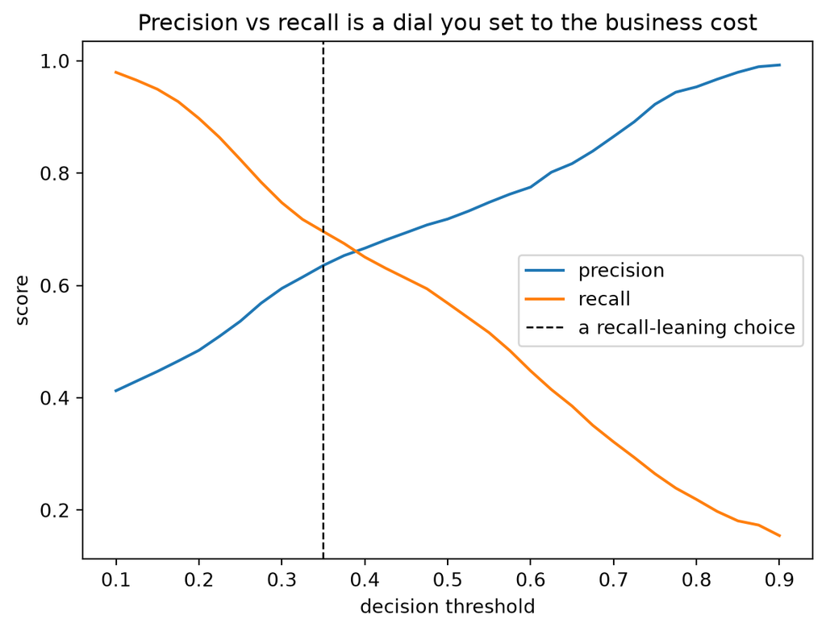

```python
# The trade-off, drawn: as the line moves left, you catch
# more but cry wolf more
grid = np.linspace(0.1, 0.9, 33)
prec = [precision_score(y_val, (probs > t).astype(int), zero_division=0) for t in grid]
rec = [recall_score(y_val, (probs > t).astype(int)) for t in grid]
plt.plot(grid, prec, label="precision")
plt.plot(grid, rec, label="recall")
plt.axvline(0.35, color="k", ls="--", lw=1,
            label="a recall-leaning choice")
plt.xlabel("decision threshold")
plt.ylabel("score")
plt.legend()
plt.title("Precision vs recall is a dial you set to the business cost")
plt.show();
```

```python
# Suppose missing a cancellation costs 4x a false alarm ->
# favor recall
chosen = 0.35
p = (probs > chosen).astype(int)
print(f"At threshold {chosen}: we catch {recall_score(y_val, p):.0%} of cancellations, "
      f"with precision {precision_score(y_val, p):.0%}.")
```

```
At threshold 0.35: we catch 70% of cancellations, with precision 64%.
```

> **GenAI tip:** Feed these numbers to an AI assistant and ask for a 3-sentence executive summary: the decision, the impact, and the main risk. Then fact-check every number it repeats before it goes in a deck.

## Walkthrough + Exercise 4.2: From Feature Importance to an AI-Drafted Executive Summary

First, open the black box. “It’s a black box” is the objection you will hear most. The simplest, model-agnostic way to see what drove the model is **permutation importance**: shuffle one feature at a time and watch how much accuracy drops. A big drop means the model leaned heavily on that feature; little drop means it barely used it.

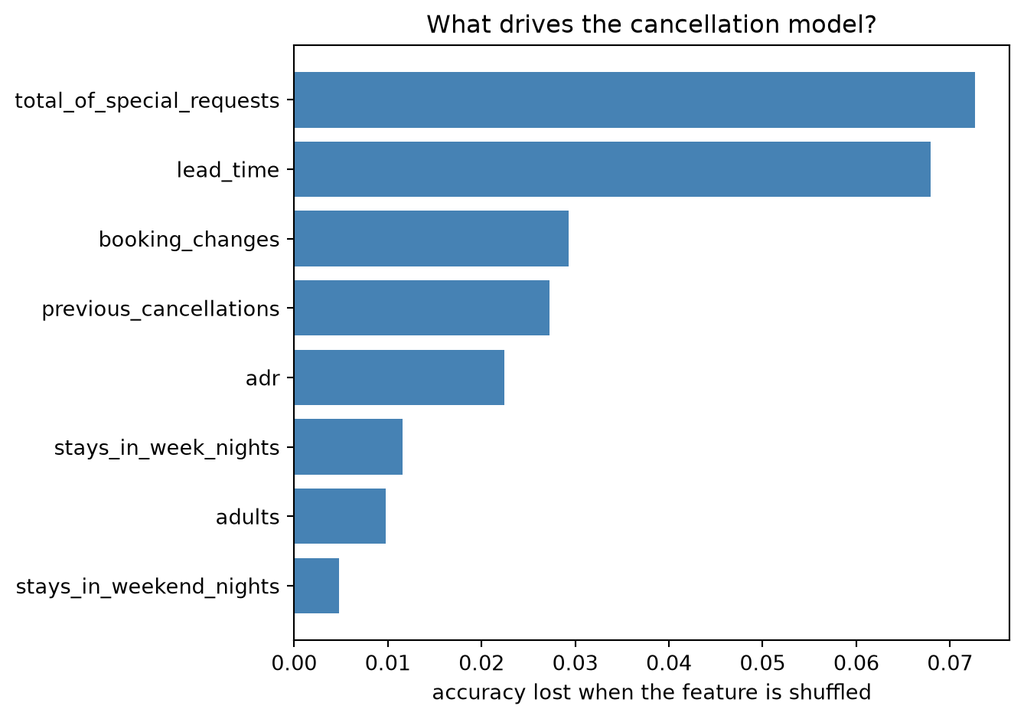

```python
# Permutation importance: shuffle each feature in turn and
# measure the accuracy it costs. Bigger drop = the model
# relied on that feature more. (Reuses the Module 1 model +
# X_val.)
import numpy as np
rng = np.random.default_rng(2026)

base_acc = ((model.predict(X_val, verbose=0).ravel() > 0.5).astype(int) == y_val).mean()
drops = []
for j in range(len(features)):
    X_shuffled = X_val.copy()
    # break this one feature's signal
    X_shuffled[:, j] = rng.permutation(X_shuffled[:, j])
    acc = ((model.predict(X_shuffled, verbose=0).ravel() > 0.5).astype(int) == y_val).mean()
    drops.append(base_acc - acc)

order = np.argsort(drops)
plt.barh([features[i] for i in order],
         [drops[i] for i in order], color="steelblue")
plt.xlabel("accuracy lost when the feature is shuffled")
plt.title("What drives the cancellation model?")
plt.tight_layout()
plt.show();
```

**Now you try:** turn the metrics *and* that “why” into a decision-ready brief with your AI assistant. The assistant drafts; you verify and own the recommendation. This is the make-or-break communication skill of the whole course.

**A prompt to start from:**

> Given these results, precision [X] and recall [Y] at a decision threshold of [T], where missing a cancellation costs about 4x a false alarm, plus the top drivers [paste the highest-importance features above]. Write a 3-sentence executive summary: the decision, the business impact, and the main risk, and end with a one-line plain-English “why.”

```python
# Scratch space for 4.2: paste your threshold's
# precision/recall and the top features here.
```

> **GenAI tip:** Check the draft against what the model actually showed: the numbers, and whether the stated “why” matches the importance chart. Fact-check every figure before it goes in a deck.

## Walkthrough 4.3: Package the Model for Deployment (TensorFlow SavedModel)

A trained model only creates value once it’s **deployed**. The industry-standard format for serving is the **TensorFlow SavedModel**, and Keras 3 can export one straight from the cancellation model we trained on the PyTorch backend (the export goes through TensorFlow, which Colab already ships):

```
%%{init: {'theme': 'base', 'themeVariables': {'fontSize': '16px'}}}%%
flowchart LR
  TR(["Trained Keras model<br/>(PyTorch backend)"]):::start --> EX["model.export()"]:::key
  EX --> SM[("TensorFlow<br/>SavedModel")]:::data
  SM --> SRV["Serving stack:<br/>TF Serving, Vertex AI"]:::accent
  SRV --> PR[/"Live<br/>predictions"/]:::good
  classDef start fill:#dbe9ff,stroke:#1a73e8,color:#1a1a1a
  classDef key fill:#fff3cd,stroke:#d39e00,color:#1a1a1a
  classDef data fill:#d1f0ec,stroke:#0b7a75,color:#1a1a1a
  classDef accent fill:#ede0ff,stroke:#6a1b9a,color:#1a1a1a
  classDef good fill:#d8f5d8,stroke:#2e7d32,color:#1a1a1a
```

Export once to a SavedModel; standard serving tools load it with no training code.

```python
# Export the trained Module 1 cancellation model as a
# TensorFlow SavedModel. `model.export()` writes a TF
# SavedModel regardless of the active Keras engine.
# -> a folder a serving stack can load
model.export("hotel_cancel_savedmodel")

# Reload it the way a deployment/serving environment would,
# then predict.
import tensorflow as tf
reloaded = tf.saved_model.load("hotel_cancel_savedmodel")
serving = reloaded.signatures["serving_default"]
print("Served predictions:",
      serving(tf.constant(X_val[:3], dtype=tf.float32)))
```

[output not shown]

> **Why a SavedModel:** it bundles the network *and* its trained weights into a language-agnostic package that TensorFlow Serving, Vertex AI, SageMaker, and most MLOps tooling load directly. No Python training code required. Same model you built in Module 1; this is how you hand it to production.

### Interpretation Questions

1. As you lower the threshold, recall rises but precision falls. Which way should a revenue team lean for cancellations, and why?
2. Write one sentence a non-technical manager would understand describing what this model does and what it’s worth.
3. What would you monitor after deployment to catch the model going stale (drift)?

### Self-Check

By the end of this module, you should be able to:

- Build and read a confusion matrix in business terms
- Compute precision, recall, and F1, and say when accuracy misleads
- Tune a decision threshold to a stated business cost
- Turn model results into a clear, honest stakeholder summary
- Export a trained model as a TensorFlow SavedModel for deployment